# R Notebook

1 MVP In this homework we’ll use the msleep data set provided in the ggplot package. It concerns the sleeping patterns of various types of mammal.

```r
library(tidyverse)
data(msleep)
```

```r
summary(msleep)
```

```
     name              genus               vore
 Length:83          Length:83          Length:83
 Class :character   Class :character   Class :character
 Mode  :character   Mode  :character   Mode  :character




    order           conservation        sleep_total      sleep_rem
 Length:83          Length:83          Min.   : 1.90   Min.   :0.100
 Class :character   Class :character   1st Qu.: 7.85   1st Qu.:0.900
 Mode  :character   Mode  :character   Median :10.10   Median :1.500
                                       Mean   :10.43   Mean   :1.875
                                       3rd Qu.:13.75   3rd Qu.:2.400
                                       Max.   :19.90   Max.   :6.600
                                                       NA's   :22
  sleep_cycle         awake          brainwt            bodywt
 Min.   :0.1167   Min.   : 4.10   Min.   :0.00014   Min.   :   0.005
 1st Qu.:0.1833   1st Qu.:10.25   1st Qu.:0.00290   1st Qu.:   0.174
 Median :0.3333   Median :13.90   Median :0.01240   Median :   1.670
 Mean   :0.4396   Mean   :13.57   Mean   :0.28158   Mean   : 166.136
 3rd Qu.:0.5792   3rd Qu.:16.15   3rd Qu.:0.12550   3rd Qu.:  41.750
 Max.   :1.5000   Max.   :22.10   Max.   :5.71200   Max.   :6654.000
 NA's   :51                       NA's   :27
```

# data set shows a few mssing values

```r
glimpse(msleep)
```

```
Observations: 83
Variables: 11
$ name         <chr> "Cheetah", "Owl monkey", "Mountain beaver", "Greater…
$ genus        <chr> "Acinonyx", "Aotus", "Aplodontia", "Blarina", "Bos",…
$ vore         <chr> "carni", "omni", "herbi", "omni", "herbi", "herbi", …
$ order        <chr> "Carnivora", "Primates", "Rodentia", "Soricomorpha",…
$ conservation <chr> "lc", NA, "nt", "lc", "domesticated", NA, "vu", NA, …
$ sleep_total  <dbl> 12.1, 17.0, 14.4, 14.9, 4.0, 14.4, 8.7, 7.0, 10.1, 3…
$ sleep_rem    <dbl> NA, 1.8, 2.4, 2.3, 0.7, 2.2, 1.4, NA, 2.9, NA, 0.6, …
$ sleep_cycle  <dbl> NA, NA, NA, 0.1333333, 0.6666667, 0.7666667, 0.38333…
$ awake        <dbl> 11.9, 7.0, 9.6, 9.1, 20.0, 9.6, 15.3, 17.0, 13.9, 21…
$ brainwt      <dbl> NA, 0.01550, NA, 0.00029, 0.42300, NA, NA, NA, 0.070…
$ bodywt       <dbl> 50.000, 0.480, 1.350, 0.019, 600.000, 3.850, 20.490,…
```

```r
dim(msleep)
```

```
[1] 83 11
```

# too many missing values to remove them

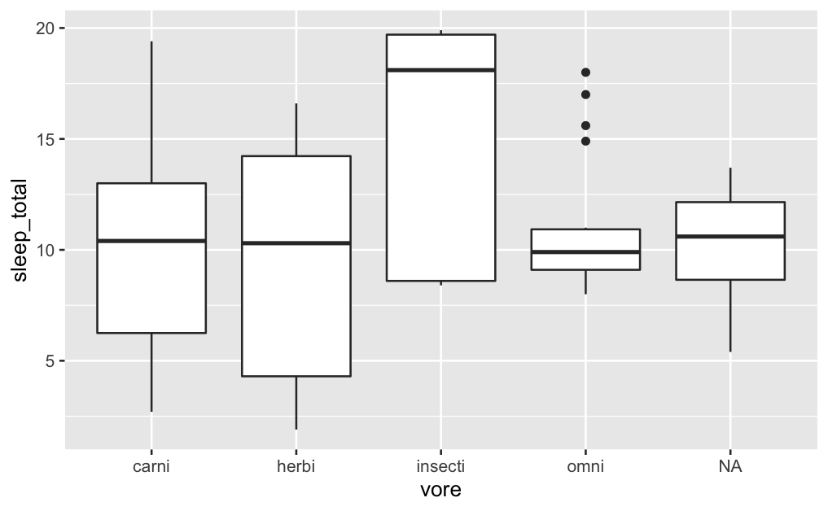

```r
ggplot(msleep) +
  aes(x = vore, y = sleep_total) +
  geom_boxplot()
```

Jabberwockies sleep for around 7 hours a night, on average. Perform an appropriate statistical test to determine whether the mean sleep_total in the sampled population of animal types differs from the typical value for jabberwockies.

Let’s see the distribution of the total_sleep

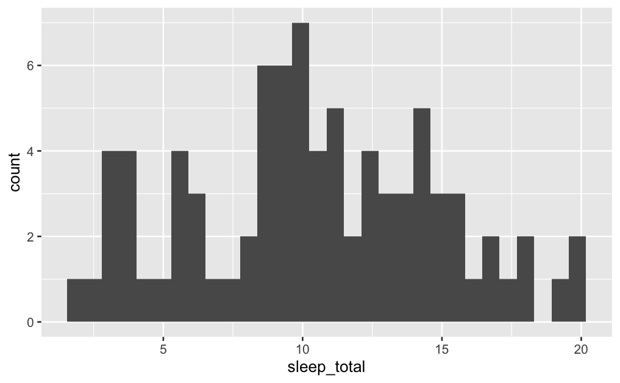

```r
ggplot(msleep) +
  aes(x = sleep_total) +
  geom_histogram()
```

Can we apply the central limit theorem?:

```r
nrow(msleep)
```

```
[1] 83
```

```r
nrow(msleep) * 7
```

```
[1] 581
```

```r
(1 - 7) * nrow(msleep)
```

```
[1] -498
```

# Let’s define the hypothesis

# alpha = 0.05

# H0: mean_sleep of the sample = 7

# H1: mean_sleep of ths sample different from 7

```r
t.test(x = msleep$sleep_total,
       mu = 7,
       alternative = "two.sided")
```

```
    One Sample t-test

data:  msleep$sleep_total
t = 7.0293, df = 82, p-value = 5.629e-10
alternative hypothesis: true mean is not equal to 7
95 percent confidence interval:
  9.461972 11.405497
sample estimates:
mean of x
 10.43373
```

# the aerage total sleep is statistically different than the one from Jabberwockies

Perform an appropriate statistical test to determine whether omnivores sleep for significantly longer than herbivores, on average. #2_sample test; independant samples # alpha = 0.05% # h0: omni_sleep - herbi_seep < = 0 # ha: omni_sleep - herbi_sleep > 0

```r
omni <- msleep %>%
  filter(vore == "omni")

herbivore <- msleep %>%
  filter(vore == "herbi")

t.test(x = omni$sleep_total, y = herbivore$sleep_total,
       alternative = "greater",
       paired = FALSE)
```

```
    Welch Two Sample t-test

data:  omni$sleep_total and herbivore$sleep_total
t = 1.3039, df = 49.974, p-value = 0.09912
alternative hypothesis: true difference in means is greater than 0
95 percent confidence interval:
 -0.4038525        Inf
sample estimates:
mean of x mean of y
10.925000  9.509375
```

# p_value > 0.05 we cannot reject the null hypothesis

Perform an appropriate statistical test to determine whether the proportion of domesticated animals in the population of animal types is greater than 5%.

# h0: prop_domesticated < = 5%

# ha: prop_domesticated > 5%

```r
num_domesticated <- msleep %>%
  filter(conservation == "domesticated") %>%
  count()

# we assum that h0 is true and proportion is 0.07
std_error <- sqrt(0.05 * (1 - 0.05) / nrow(msleep))

# check normal assumption
0.05 * nrow(msleep) >= 10
```

```
[1] FALSE
```

```r
(1-0.05) * nrow(msleep) >= 10
```

```
[1] TRUE
```

# we fail to meet the assumption so we’ll use a binomial test

```r
binom.test(x = num_domesticated$n,
           n = nrow(msleep),
           p = 0.05,
           alternative = "greater")
```

```
    Exact binomial test

data:  num_domesticated$n and nrow(msleep)
number of successes = 10, number of trials = 83, p-value =
0.008439
alternative hypothesis: true probability of success is greater than 0.05
95 percent confidence interval:
 0.06684379 1.00000000
sample estimates:
probability of success
             0.1204819
```

#p value is less than 0.05 we can reject the null hypothesis and say that the proportion of domesticated animals is greater than 5%

Determine an appropriate sample size for the following problem:

A quality analyst wants to estimate a 99% confidence interval to within ±0.01g for the mean weight of fruit pastels produced by a production line tomorrow. Prior evidence suggests the standard deviation in fruit pastel weights is 0.05g. What is the minimum number of fruit pastels the analyst should sample?

```r
n <- (qnorm(0.995)^2 * 0.05^2) / 0.01^2
n
```

```
[1] 165.8724
```

# we need at least 166fruit pastel for this

Determine an appropriate sample size for the following problem:

A clinical dietician wants to compare two different diets, A and B, for diabetic patients. She hypothesizes that diet A (Group 1) will be different from diet B (Group 2), in terms of mean blood glucose. She plans to get a random sample of diabetic patients and randomly assign them to one of the two diets. At the end of the experiment, which lasts 6 weeks, a fasting blood glucose test will be conducted on each patient. She also expects that the average difference in blood glucose measure between the two group will be about 10 mg/dl. Furthermore, she also assumes the standard deviation of blood glucose distribution for diet A to be 15 mg/dl and the standard deviation for diet B to be 17 mg/dl. The dietician wants to know the number of subjects needed in each group assuming equal sized groups.

```r
library(WebPower)
s_pooled <- sqrt((15^2 + 17^2)/2)
d_glucose <- 10/s_pooled

 wp.t(n1 = NULL,
      d = d_glucose,
      alpha = 0.05,
      power = 0.8,
      type = "two.sample",
      alternative = "two.sided")
```

```
Two-sample t-test

           n         d alpha power
    41.32581 0.6237829  0.05   0.8

NOTE: n is number in *each* group
URL: http://psychstat.org/ttest
```

What would the power of the test above be if the number of patients in each group was 100?

```r
 wp.t(n1 = 100,
      d = d_glucose,
      alpha = 0.05,
      power = NULL,
      type = "two.sample",
      alternative = "two.sided")
```

```
Two-sample t-test

      n         d alpha     power
    100 0.6237829  0.05 0.9924372

NOTE: n is number in *each* group
URL: http://psychstat.org/ttest
```